# Analiza danych - laboratorium 9

Korelacja, test chi kwadrat

Adrian Kowalski

Politechnika Krakowska

# Zadanie

W pliku *lab9t.csv* znajdują się dane zawierające średnią ilość godzin snu w tygodniu 36 studentów oraz ich wyniki na egzaminie końcowym z Rachunku Prawdopodobieństwa. Czy ilość godzin snu ma wpływ na wynik? Jaki?

```r
scores <- read_csv('lab9t.csv')
scores
```

| sleep | score |
| --- | --- |
| 7.55 | 96 |
| 7.47 | 98 |
| 8.55 | 92 |
| 9.42 | 98 |
| 7.54 | 97 |
| 8.07 | 97 |
| 8.62 | 91 |
| 4.77 | 96 |
| 8.79 | 95 |
| 8.89 | 99 |

[output cut: 26 more lines]

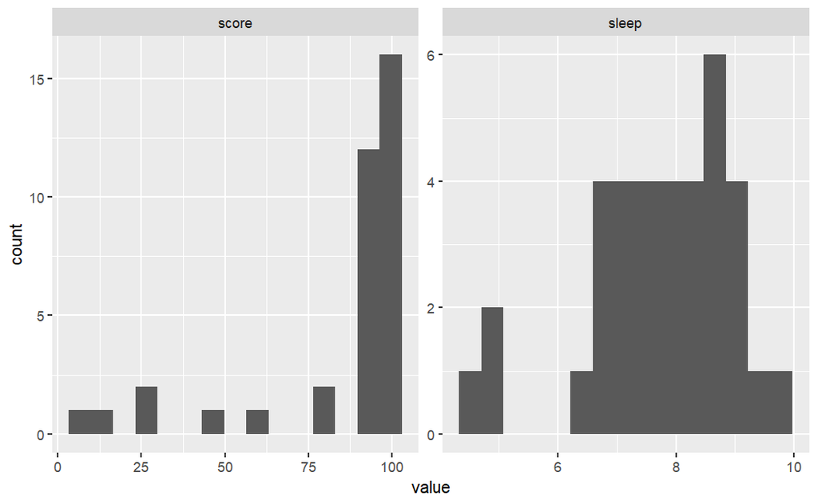

```r
scores2 <- scores %>% pivot_longer(1:2, names_to='variable', values_to='value')
ggplot(scores2, aes(x=value)) + geom_histogram(bins=15) + facet_wrap(~variable, scales='free')
```

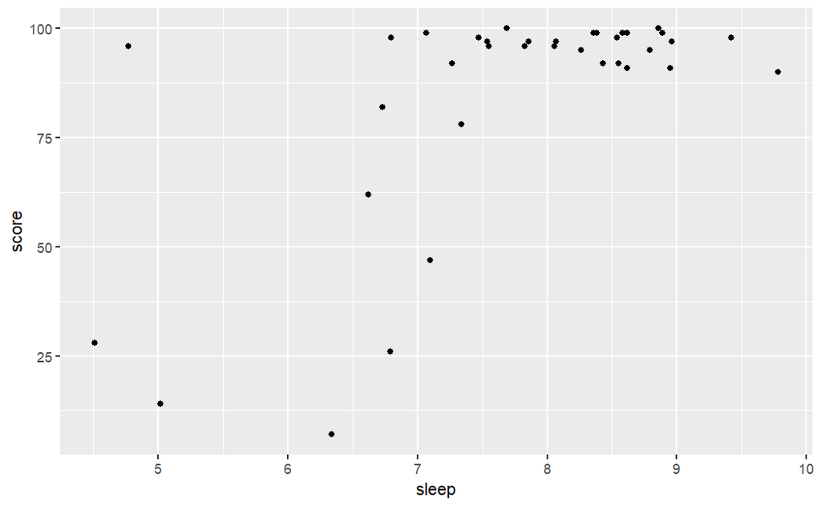

```r
ggplot(data=scores, aes(x=sleep, y=score)) + geom_point()
```

# Współczynnik korelacji Pearsona

W momencie, gdy mamy doczynienia z dwiema zmiennymi ilościowymi, możemy wyliczyć ich współczynnik korelacji Pearsona z próby. Jest on dany wzorem

$$r_{xy} = \frac{\sum_{i=1}^n (x_i -
\bar{x})(y_i - \bar{y})}{\sqrt{\sum_{i=1}^n (x_i -
\bar{x})^2}\sqrt{\sum_{i=1}^n (y_i - \bar{y})^2}}.$$

Ten współczynnik jest zawsze zawarty w przedziale $[-1,1]$.

Interpretacja “siły” korelacji w bardzo duży sposób zależy od danych. Czasami korelacja $0.8$ może być uznana za “niską”, a czasami $0.4$ może być uznana za wysoką. Są to jednak szczególne przypadki. Ogólną zasadą jest uznanie $|r_{xy}| > 0.75$ za dużą korelację, $|r_{xy}| < 0.25$ za niską korelacje.

W *R* wyznaczamy współczynnik korelacji Pearsona za pomocą *cor()* (domyślnym parametrem *type = ‘pearson’*).

```r
cor(scores$sleep, scores$score)
```

```
[1] 0.6357966
```

Przy założeniu normalności obu prób, których korelacje liczymy jesteśmy w stanie wyznaczyć parametryczny test na istotność statystyczną współczynnika korelacji. Wówczas statystyka testowa ma rozkład $t$-studenta o $n-2$ stopniach swobody i ma postać

$$t = \frac{r}{\sqrt{1-r^2}}\sqrt{n-2}.$$

```r
cor.test(scores$sleep, scores$score)
```

```
    Pearson's product-moment correlation

data:  scores$sleep and scores$score
t = 4.8031, df = 34, p-value = 3.088e-05
alternative hypothesis: true correlation is not equal to 0
95 percent confidence interval:
 0.3883882 0.7977060
sample estimates:
      cor
0.6357966
```

# Metody nieparametryzne

### Bootstrap

Oczywiście, mamy również metody wyznaczania przedziałóW ufności i tetstów istotności, które nie zakładają normalności naszych prób. Możemy znowu powołać się na metodę bootstrap.

### Test permutacyjny

Ideą testu permutacyjnego jest założenie, że korelacja w naszych danyhc jest przypadkowa. W ten sposób tworzymy “odpowiednią” ilość prób, gdzie kolumna z pierwszą zmienną jest niezmieniona, a kolumna z drugą zmienną jest permutowana.